# suezalla

# suezalla: A custom ggplot2 theme and colour palette

`suezalla` is a lightweight R package that provides:

- Custom `ggplot2` themes: `theme_magazine()`, `theme_latex()`, `theme_zombie()`, `theme_academic1940()`, and `theme_academic1940_pattern()`
- Several curated colour palettes inspired by polaroids, jam jars, retro aesthetics, zombies, and classic scientific graphics
- Pattern fill utilities for `ggpattern`, including `suezalla_academic_style()`
- Custom scale functions: `scale_colour_suezalla()` and `scale_fill_suezalla()`

These tools help you create clean, consistent, or stylistically bold visualizations with minimal effort.

## Installation

Install the development version of `suezalla` from GitHub using `devtools`:

```r
# If not already installed
install.packages("devtools")

# Install suezalla
devtools::install_github("sucanavan/suezalla")
```

## Available palettes

> **Note:** The `npg` palette is based on the Nature Publishing Group (NPG) color scheme as provided by the [`ggsci`](https://cran.r-project.org/package=ggsci) package.

| Palette | Colours |
| --- | --- |
| `polaroid` |  |
| `vibrant` |  |
| `jam` |  |
| `corporate` |  |
| `lively1` |  |
| `lively2` |  |
| `retro` |  |
| `autumn` |  |
| `zombie` |  |
| `academic` |  |
| `npg` |  |

## Using palettes in code

To extract colours programmatically from a palette, use the `suezalla_palette()` function.

### Arguments:

- `palette_name`: The name of the palette you want to use, such as `"jam"` or `"autumn"`.
- `n`: The number of colours to return.
- `type`: `"discrete"` for exact colours or `"continuous"` for a smooth gradient (interpolated).

### Examples:

```r
# Return 4 discrete colours from the 'jam' palette
suezalla_palette("jam", n = 4)
```

```
## [1] "#FBC9BE" "#DB7B65" "#ECB865" "#695356"
```

```r
# Return 10 interpolated colours from the 'autumn' palette as a gradient
suezalla_palette("autumn", n = 10, type = "continuous")
```

```
##  [1] "#388388" "#42A4A5" "#51BDB5" "#74B592" "#9FB578" "#D3BF6E" "#ECB867"
##  [8] "#F2A562" "#EE8B59" "#E76F51"
```

## Fonts

These are handled automatically via `sysfonts` and `showtext` when the package is attached.

## Quick examples

### LaTeX academic plot

This plot uses `theme_latex()`, a clean black-and-white theme with a serif font designed to resemble LaTeX-style figures. It is ideal for academic publications with strict formatting requirements.

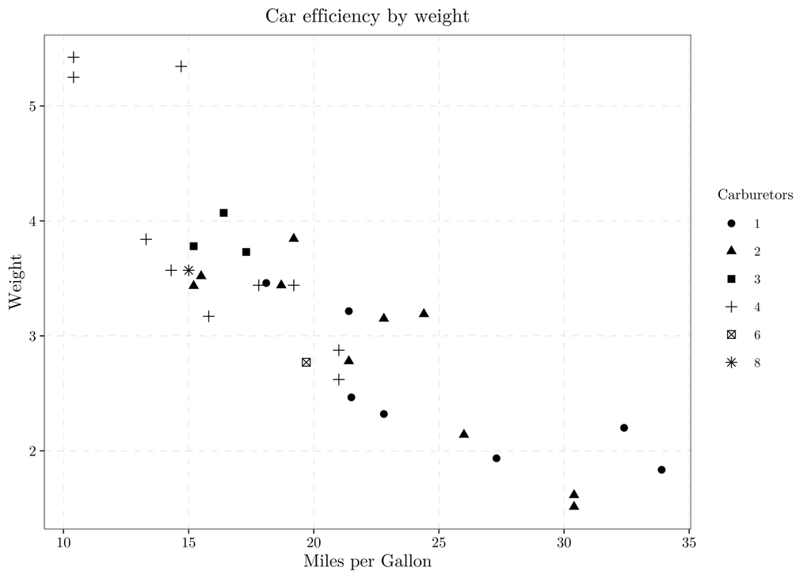

```r
ggplot(mtcars, aes(x = mpg, y = wt, shape = factor(carb))) +
  geom_point(size = 2, stroke = 0.4) +
  theme_latex() +
  labs(
    title = "Car efficiency by weight",
    x = "Miles per Gallon",
    y = "Weight",
    shape = "Carburetors"
  )
```

### Academic 1940

This example applies `theme_academic1940()`, inspired by mid-20th-century scientific plots. It uses black outlines, serif fonts, and simple geometry to evoke a retro academic aesthetic.

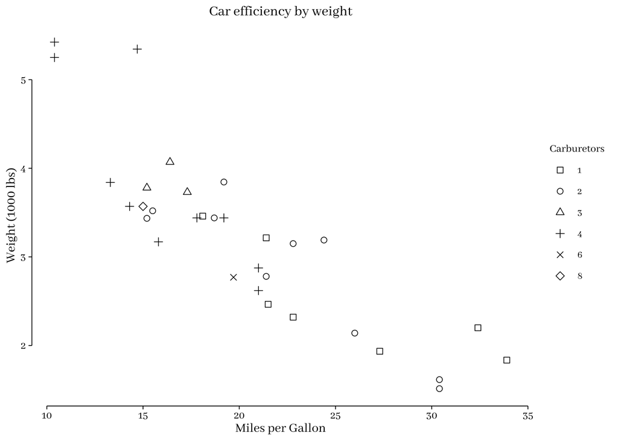

```r
ggplot(mtcars, aes(x = mpg, y = wt, shape = factor(carb))) +
  geom_point(size = 2, stroke = 0.4, color = "black", fill = "white") +
  scale_shape_manual(values = c(0, 1, 2, 3, 4, 5)) +
  theme_academic1940() +
  labs(
    title = "Car efficiency by weight",
    x = "Miles per Gallon",
    y = "Weight (1000 lbs)",
    shape = "Carburetors"
  )
```

### Academic pattern style

This example demonstrates `theme_academic1940_pattern()`, designed for black-and-white print or accessibility needs. It uses shape patterns (via `ggpattern`) instead of color fills.

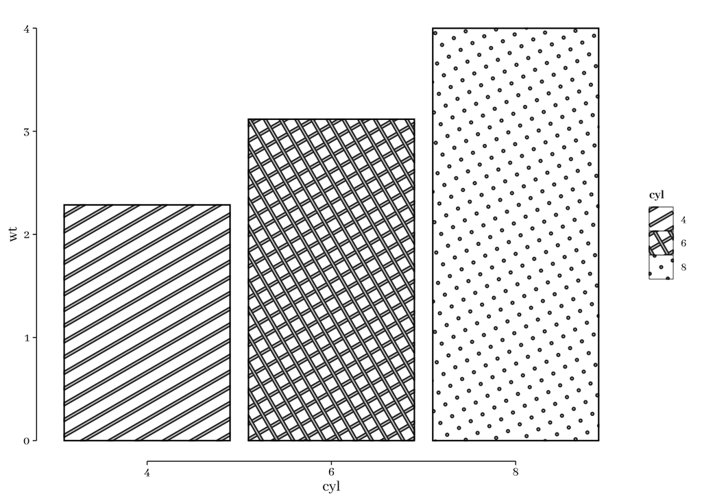

```r
df <- aggregate(wt ~ cyl, data = mtcars, FUN = mean)
df$cyl <- factor(df$cyl)

ggplot(df, aes(x = cyl, y = wt, fill = cyl, pattern = cyl)) +
  theme_academic1940_pattern(n = 3)
```

### Magazine theme

The `theme_magazine()` style is designed for modern visuals with a bold font and clean grid-free layout. Combined with the `corporate` color palette, it gives a contemporary data journalism vibe.

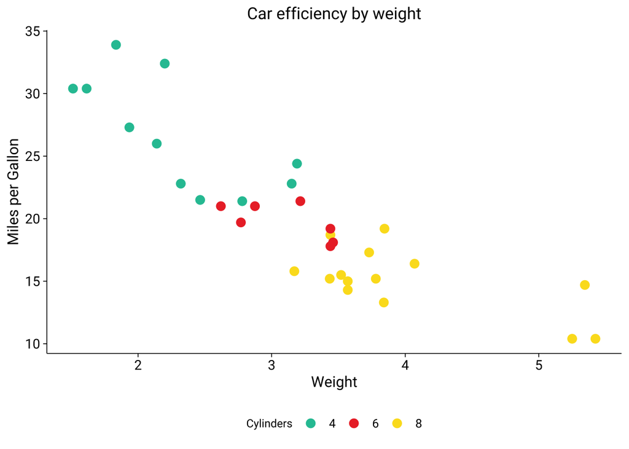

```r
ggplot(mtcars, aes(x = wt, y = mpg, colour = factor(cyl))) +
  geom_point(size = 3) +
  scale_colour_suezalla(palette_name = "corporate") +
  theme_magazine() +
  theme(
    axis.ticks = element_line(size = 0.3),
    axis.ticks.length = unit(3, "pt")
  ) +
  labs(
    title = "Car efficiency by weight",
    x = "Weight",
    y = "Miles per Gallon",
    colour = "Cylinders"
  )
```

### Zombie theme

A playful and gritty theme (`theme_zombie()`) with a hand-drawn feel, using the XKCD font if available. Intended for creative or informal visualizations.

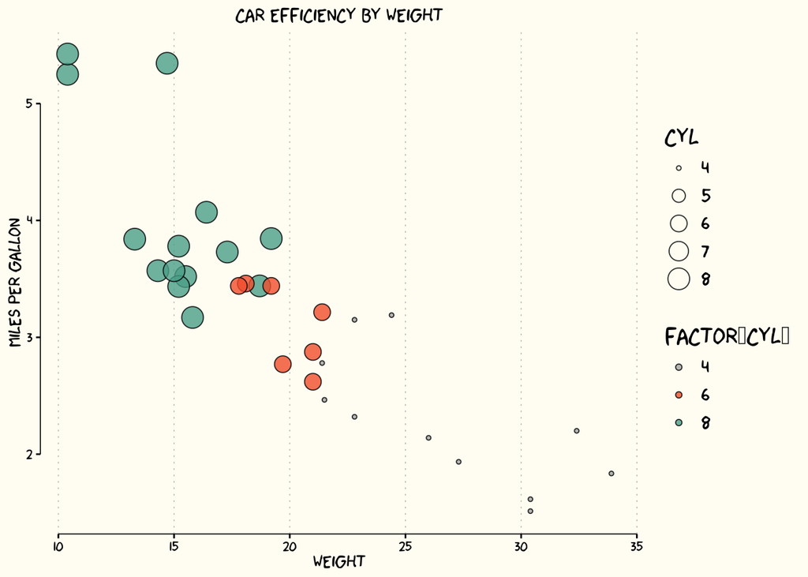

```r
ggplot(mtcars, aes(y = wt, x = mpg)) +
  geom_point(aes(fill = factor(cyl), size = cyl), shape = 21, alpha = 0.8) +
  scale_fill_suezalla(palette_name = "zombie") +
  theme_zombie() +
  labs(
    title = "Car efficiency by weight",
    x = "Weight",
    y = "Miles per Gallon",
    colour = "Cylinders"
  )
```